# BrunoLima_T3_QUIZ_S11.Rmd

Bruno Lima Queiroz Santos

DUE 22/11/2019

O estimador pontual para $p$, também denominado proporção amostral de sucessos, é definido como $p$^ $= X/n$, onde:  
$X$ denota o número de elementos que apresentam a característica.

Considerando $X$ o número de eleitores que votarão em um determinado candidato, a variável $X$ tem distribuição binomial $X \approx Bin(n,p)$, onde $n$ denota o número de um mesmo evento binomial experimentado e $p$ a probabilidade de cada evento experimentado ser sucesso.

Uma observação importante é que ao analisar uma sequência de $n$ experimentos, não se obtém necessariamente $n*p$ sucessos. Mas, quanto mais se realiza essa sequência de eventos, mais os resultados obtidos se tornam distribuídos,isto é, acumulam a aleatoriedade e se aproximam de serem resultados contínuos, isto é, a densidade dos valores se aproxima da distribuição prevista. Assim, 1000 replicações é suficiente para se aproximar suficientemente a distribuição discreta de uma contínua.

Assim, aumentando-se o número de replicações, geram-se resultados distribuídos de forma cada vez mais contínua em vez de descontínua.Logo,**1000 replicações é suficiente para se aproximar suficientemente a distribuição discreta de uma contínua**.

O valor de $n$, isto é, do tamanho da sequência de experimentação está ligado à aproximação da distribuição normal. Ele é o limite superior da distribuição gerada, pois você só obtém no máximo $n$ sucessos. Alterações em n provocam mudanças no pico da distribuição suficientemente contínua pelo $k$, assim na variância, e no alongamento dela, em direção à uma distribuição normal.

```r
p<-0.5 #probability of success in each independent event.
n<-10000000 # n trials for each sample. But the result is actually the number of success in the end of n trials.
k<-1000 # 1000 Replicações (1000 resultados/pontos) é suficiente.
m<-p*(1-p)
```

Gera-se um vetor com quantis de $0$ a $1$. Quantil $C$ é o valor focado para a variável assumir. Ou seja, $X=C$.

```r
x <- seq(0,n,by = 1)
#X é um vetor com os quantis de 0 a n por 1.

X<-rbinom(k,#replicações
          n,#número de tentativas, limite superior de sucessos
          p)#probabilidade de cada sucesso
#Y<-dnorm(x,p*k,k*m)
#Z<-rnorm(x,p*k,k*m)
```

A função densidade de probabilidade da distribuição normal é denotada por:

$$f(x)=\frac{1}{
\sigma \sqrt{2\pi}
}
e^{-\frac{1}{
2
}(\frac{x-\mu}{\sigma})^{2}
}$$

Neste caso, diz-se, como na literatura, que:

$$X \sim N(\mu, \sigma^{2})$$
Porém, é preciso cautela, pois `dnorm` refere-se a:
$$X \sim N(\mu, \sigma)$$

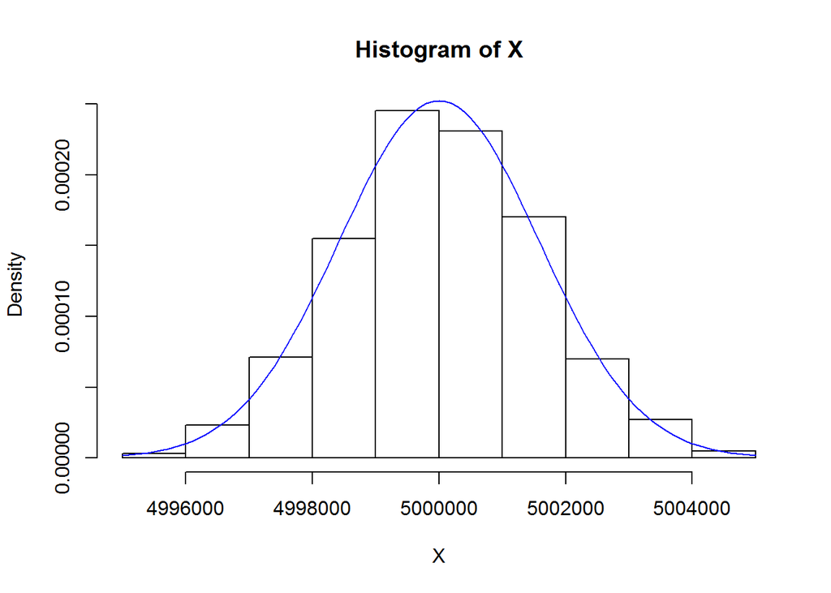

```r
hist(X,
     prob=TRUE
     )



curve(dnorm(Vector_Of_Quantiles<-x,#quantís, média[esperança]
            Mean<-p*n,
            Standard_Deviation<-sqrt(n*m)#Take care, STD ISN'T Variance.STD[DESVIO PADRÃO,raiz quadrada da variança]
            ),
            add=T,#Comando de adicionamento à exibição/representação acima.
            col="blue")
```

```r
### dnorm( quantís, média[esperança], STD[DESVIO PADRÃO,raiz quadrada da variança])
#plot(dbinom(x,n,p))
#curve(dnorm(x,p*n,sqrt(n*m)),add=T,col="blue")
```

**OBS,É ERRADO ACHAR QUE:**
$$n \rightarrow \infty \Rightarrow q^{n-k} \rightarrow q^{n}$$
, porque,
$$\lim\limits_{n\to \infty}\frac{q^{n-k}}{q^{n}}=q^{-k} \neq 1$$
$$n \rightarrow \infty \Rightarrow \frac{n!}{(n-k)!} \rightarrow n(n-1)...(n-k+1) \rightarrow n^{k}$$
, pois há de $0$ ao termo $k-1$.

$$\Rightarrow\frac{n!}{(n-k)!k!}p^{n}q^{n-k}\rightarrow\frac{n^{k}}{k!}(pq)^{n}q^{-k}$$

Para grandes valores de $n$, sua variação se aproxima de variações contínuas, porque **uma variação decimal é uma variação relativa muito pequena**, logo $n \rightarrow x$.

$$\Rightarrow\frac{n!}{(n-k)!k!}p^{n}q^{n-k}\rightarrow\frac{(x/q)^{k}}{k!}(pq)^{x}$$

Assim,$f(X=k)=\frac{(x/q)^{k}}{k!}(pq)^{x}$ representa a probabilidade de obter-se k sucessos em uma sucessão de n experimentos, $n \to \infty$, ou seja $n$ **muito grande** com $n p_n \to \lambda \;\;\;,\;\; n \to \infty$ !

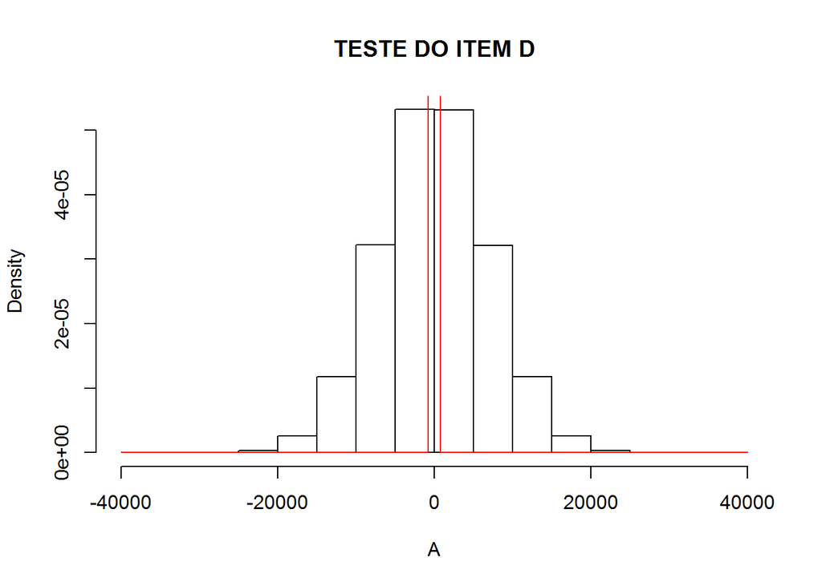

```r
n<-10000000
x<-seq(0,n,by=1)
p=0.3
# getting numbers for a sample
Z<-rnorm(sample_quantiles<-x,
         mean=p,
         sd=sqrt(p*(1-p)/n)
         )
A<-Z
A<-A-p
b<-(p*(1.0-p)/n)
#b<-sqrt(b)
A<-A/b

hist(A,
     prob=T,
     main="TESTE DO ITEM D")
curve(dnorm(x,
            mean=0,
            sd=1
            ),
      col="red",
      add=T)
```

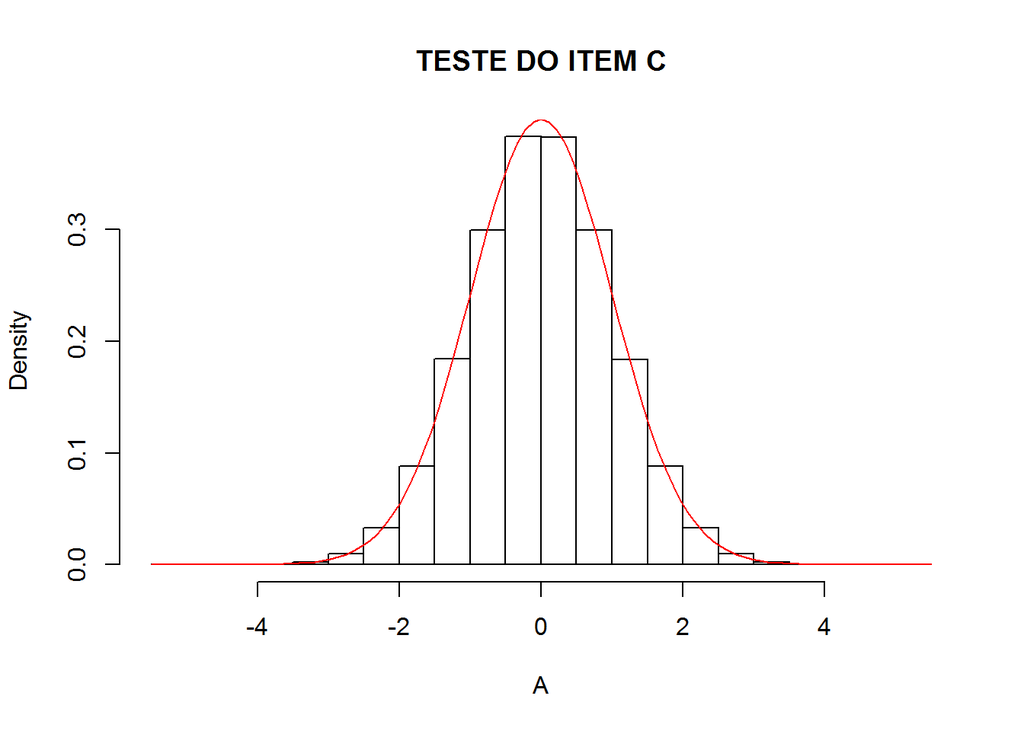

```r
A<-Z
A<-A-p
b<-(p*(1.0-p)/n)
b<-sqrt(b)
A<-A/b


hist(A,
     prob=T,
     main="TESTE DO ITEM C")
curve(dnorm(x,
            mean=0,
            sd=1
            ),
      col="red",
      add=T)
```

De onde se oberva que a *padronização* de uma variável
$$X \sim N(\mu,\sigma^{2})$$
para

$$Z=\frac{X-\mu}{\sigma} \Rightarrow Z \sim N(0,1)$$

## 2ª Questão

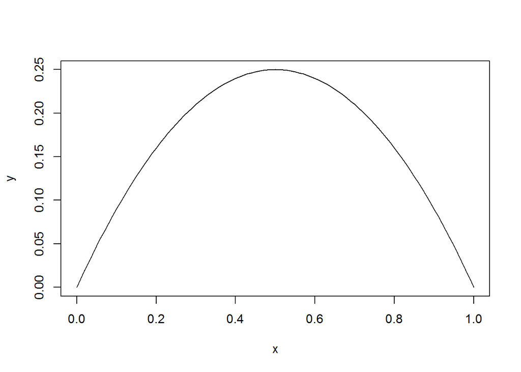

```r
F = function(x){
  return (x*(1.0-x))
}
curve(F,
      from=0,
      to=1.0,
      xlab="x",
      ylab="y")
```

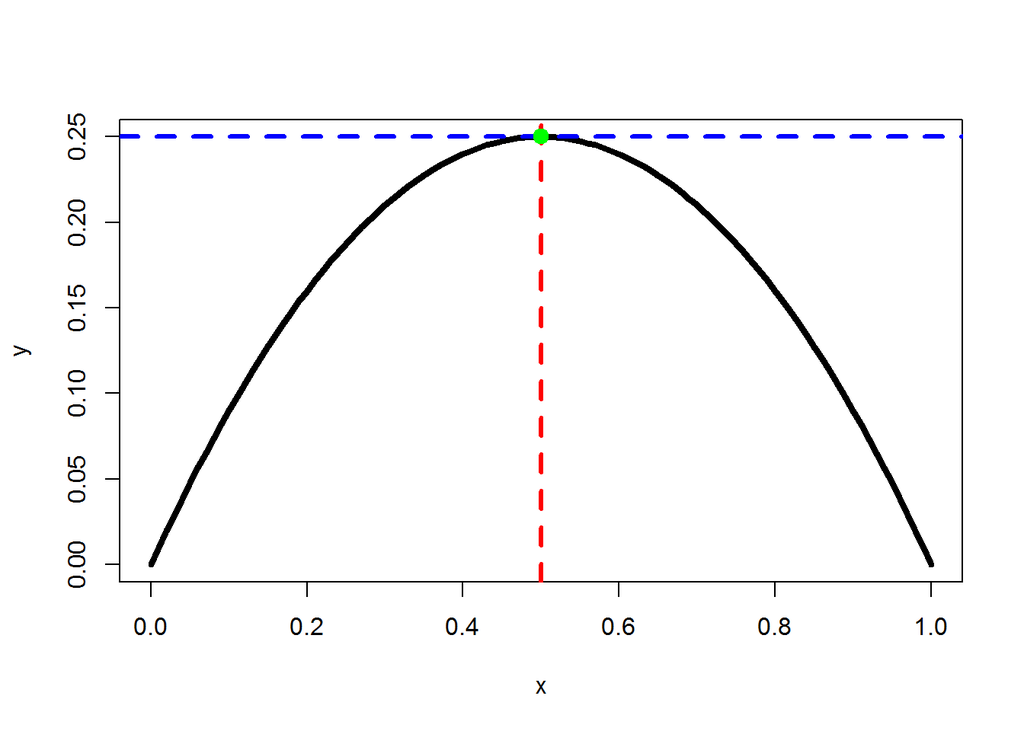

```r
plot(F,
      from=0,
      to=1.0,
      xlab="x",
      ylab="y",
     type="l",
     lwd=4)
abline(v=0.5,
       col="red",
      lty=2,
      lwd=3)
abline(h=0.25,
       col="blue",
      lty=2,
      lwd=3)
points(x<-0.5,y<-0.25,col="green",
       pch=19,
       lwd=4)
```

## 3ª Questão

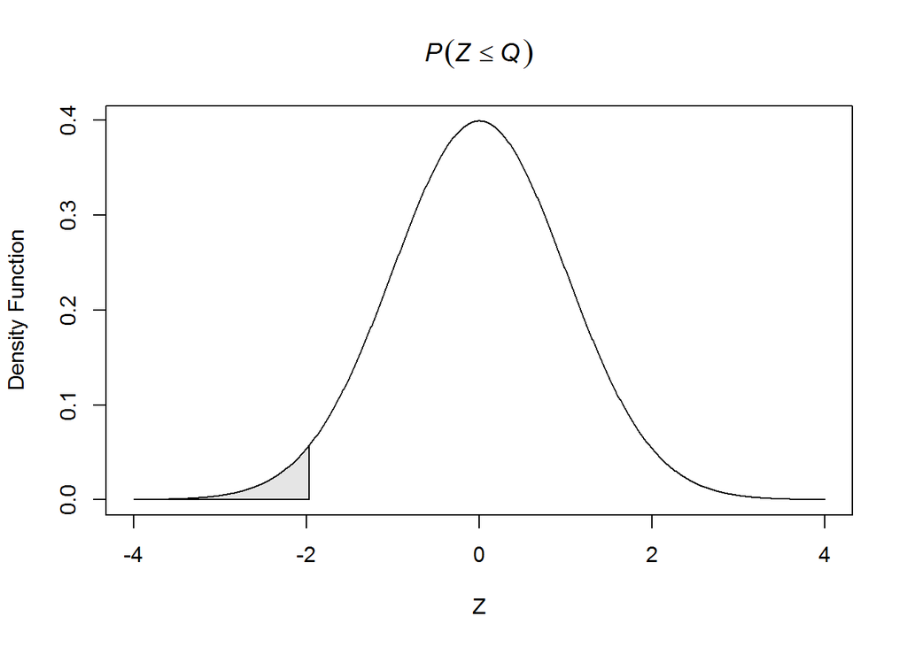

```r
#(1-α)<-0.95
##α/2<-0.05/2=0.025
###β<-0.025
x<-seq(from=-4,to=4,length=1000)
Z<-dnorm(x)# Default: mean=0, sd=1 (Standard_Deviation) != Variance.
plot(x,Z,
     #axes=F, #RETIRA OS EIXOS.
     type="l",
     xlab="Z",
     ylab="Density Function",
     main=expression(italic(P(Z<=Q)))
     )
β<-0.025

xl<-x[x<=qnorm(β)];yl<-dnorm(xl)
x2<-c(-4,xl,xl[length(xl)],-4);y2<-c(0,yl,0,0)
polygon(x2,y2,col='grey90')
```

O comando a `qnorm(p)` fornece o quantil $Q$, isto é, o valor $Z=Q$, tal que $P[Z\leq Q]= P_{Q}$ . **O quantil está relacionado à probabilidade acumulada**

```r
#(1-α)<-0.95
##α/2<-0.05/2=0.025
###β<-0.025

β<-0.025
z<-qnorm(β)
z<-abs(z)
E<-0.02
n<-0.25*((z/E)**2)
print(n)
```

```
## [1] 2400.912
```

## 4ª questão

```r
#(1-α)<-0.95
##α/2<-0.05/2=0.025
###β<-0.025

β<-0.025
z<-qnorm(β)
z<-abs(z)
E<-0.03
n<-0.25*((z/E)**2)
print(n)
```

```
## [1] 1067.072
```

## 5ª Questão

```r
β<-0.025
z<-qnorm(β)
z<-abs(z)

p<-0.54
n<-3010

#OPERATIONS
E<-p*(1-p)/n
E<-sqrt(E)
E<-E*z

V<-c(p-E,p+E)

print(V)
```

```
## [1] 0.5221951 0.5578049
```

## 6ª questão

### Item c

```r
#(1-α)<-0.95
##α/2<-0.05/2=0.025
###β<-0.025
p<-0.5
β<-0.025
z<-qnorm(β)
z<-abs(z)
E<-0.02
n<-p*(1.0-p)*((z/E)**2)
print(n)
```

```
## [1] 2400.912
```